# R3: Gathering, Cleaning data, 2022

**NICAR 2022: Atlanta, Georgia**  
v. 3-4-2022

```
Rob Wells, Ph.D.
Philip Merrill College of Journalism
University of Maryland
robwells@umd.edu
LinkedIn: https://www.linkedin.com/in/rob-wells-7929329/
```

**Goals:**

Pull data into R through various means, including accessing APIs and web URLs Clean and structure the data for analysis

– **What is an API**

APIs - basics

```
https://medium.com/@LewisMenelaws/a-beginners-guide-to-web-apis-and-how-they-will-help-you-23923a0da450

A gentle introduction to APIs for data journalists
https://trendct.org/2016/12/29/fetching-airport-delays-with-python-a-gentle-guide-to-apis-for-journalists/
```

Housekeeping

```r
#setwd("C:/Users/nmradmin/Desktop/hands_on_classes/20220305_r_3_gathering_and_cleaning_data_saturday_repeat_3039")
```

# Import from an API

– **Software: jsonlite**

```r
vignette("json-apis", package = "jsonlite")
```

– **Example: Racing Data**

```r
res <- fromJSON('http://ergast.com/api/f1/2004/1/results.json')
View(res)
```

– **Nested list**

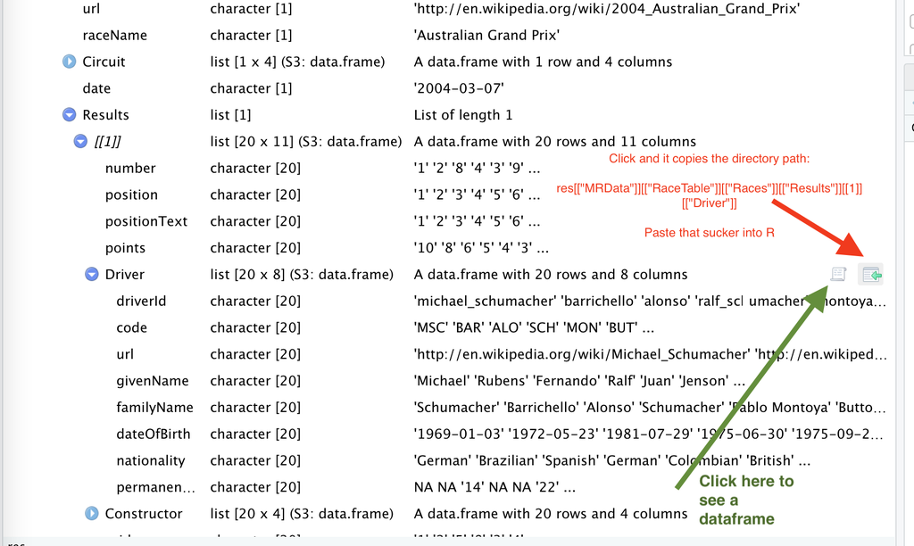

– **Click on green arrow icon and that will display path directory in the console in R Studio Copy that path into your code

– **Unpack it**

```r
drivers <- res[["MRData"]][["RaceTable"]][["Races"]][["Results"]][[1]][["Driver"]]
```

```r
colnames(drivers)
```

```
## [1] "driverId"        "code"            "url"             "givenName"       "familyName"
## [6] "dateOfBirth"     "nationality"     "permanentNumber"
```